# Lecture 6: Working with Data Part 2

Nick Huntington-Klein

January 23, 2019

## Recap

- We can get `data.frame`s by making them with `data.frame()`, or reading in data with `data()` or `read.csv`
- `data.frame`s are a list of vectors - we know vectors!
- We can pull the vectors back out with `$`
- We can assign new variables, or update them, using `$` as well

## Today

- We are going to continue working with `data.frame`s/`tibble`s
- And we’re going to introduce an important aspect of data analysis: *splitting the data*
- In other words, selecting only *part* of the data that we have
- In other words, to *subset* the data

## Why?

- Why would we want to do this?
- Many statistical questions require us to!
- We might be interested in how a variable *differs* for two different groups
- Or how one variable *is related* to another (i.e. how A looks for different values of B)
- Or how those relationships differ for different groups

## Example

- Let’s read in some data on male heights, from Our World in Data, and look at it
- Always look at the data before you use it!
- It has height in CM, let’s change that to feet

```r
df <- read.csv('http://www.nickchk.com/average-height-men-OWID.csv')
str(df)
```

```
## 'data.frame':    1250 obs. of  4 variables:
##  $ Entity  : Factor w/ 152 levels "Afghanistan",..: 1 1 1 2 2 2 3 3 3 4 ...
##  $ Code    : Factor w/ 152 levels "AFG","AGO","ALB",..: 1 1 1 3 3 3 41 41 41 2 ...
##  $ Year    : int  1870 1880 1930 1880 1890 1900 1910 1920 1930 1810 ...
##  $ Heightcm: num  168 166 167 170 170 ...
```

```r
df <- df %>% mutate(Heightft = Heightcm/30.48)
```

## Example

- If we look at height overall we will see that mean height is 167.64728
- But if we look at the data we can see that some countries aren’t present every year. So this isn’t exactly representative

```r
table(df$Year)
```

```
##
## 1810 1820 1830 1840 1850 1860 1870 1880 1890 1900 1910 1920 1930 1940 1950
##   35   28   29   41   49   59   72   80   82   86   80   85   91   72   91
## 1960 1970 1980
##   89   88   93
```

## Example

```
## # A tibble: 6 x 2
##   Entity  Heightft
##   <chr>      <dbl>
## 1 Congo       5.44
## 2 France      5.52
## 3 Gabon       5.52
## 4 Germany     5.61
## 5 Nigeria     5.48
## 6 UK          5.60
```

## Example

- What questions does this answer?
  - What is average height of men over this time period?
  - How does average height differ across countries?
- What can’t we answer yet?
  - How has height changed over time?
  - What causes these height differences [later!]

## Example

- If we want to know how height changed over time, we need to evaluate each year separately too.

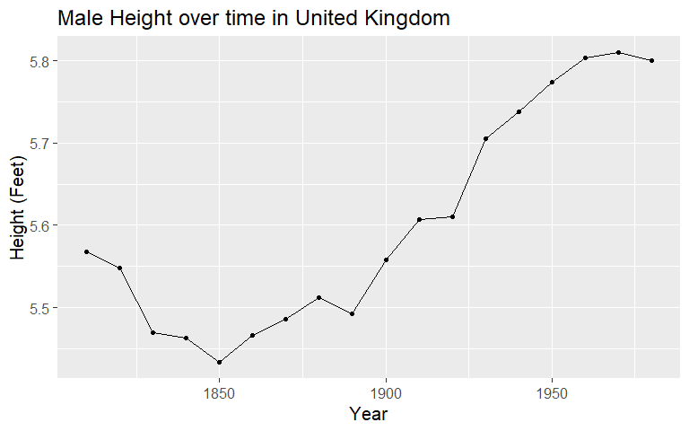

## Example

- To compare the changes over time ACROSS countries, we evaluate separately by each year AND each country

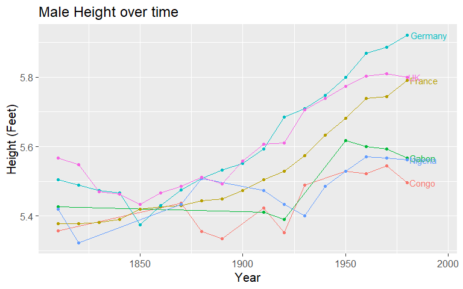

## Example

- You can see how subsetting can tell a much more complete story than looking at the aggregated data!
- So how can we do this subsetting?
- There are plenty of ways
- For today we’re going to focus on the `filter()` and `select()` commands.
- We’ll also learn to write a `for` loop.

## Subset

- The `filter()` and `select()` commands will allow you to pick just certain parts of your data
- You can select certain *rows*/observations using logicals with `filter()`
- And you can select certain *columns*/variables with `select()`
- The syntax is:

```r
data.frame %>% filter(logical.for.rows)
filter(data.frame, logical.for.rows)
data.frame %>% select(variables,you,want)
select(data.frame,variables,you,want)
```

## Subset for observations

- Let’s start by selecting rows from our data
- We do this by creating a logical - `filter` will choose all the observations for which that logical is true!
- Here’s the logical I used to pick those six countries: `Code %in% c('GBR','DEU','FRA','GAB','COD','NGA')`
- This will be equal to `TRUE` if the `Code` variable is `%in%` that list of six I gave

## Subset for observations

- We can use this logical with the `filter` command in dplyr - note I don’t need to store the logical as a variable first

```r
str(df)
```

```
## 'data.frame':    1250 obs. of  5 variables:
##  $ Entity  : Factor w/ 152 levels "Afghanistan",..: 1 1 1 2 2 2 3 3 3 4 ...
##  $ Code    : Factor w/ 152 levels "AFG","AGO","ALB",..: 1 1 1 3 3 3 41 41 41 2 ...
##  $ Year    : int  1870 1880 1930 1880 1890 1900 1910 1920 1930 1810 ...
##  $ Heightcm: num  168 166 167 170 170 ...
##  $ Heightft: num  5.52 5.44 5.47 5.58 5.57 ...
```

```r
dfsubset <- df %>% filter(Code %in% c('GBR','DEU','FRA','GAB','COD','NGA'))
str(dfsubset)
```

```
## 'data.frame':    84 obs. of  5 variables:
##  $ Entity  : Factor w/ 152 levels "Afghanistan",..: 38 38 38 38 38 38 38 38 38 38 ...
##  $ Code    : Factor w/ 152 levels "AFG","AGO","ALB",..: 28 28 28 28 28 28 28 28 28 28 ...
##  $ Year    : int  1810 1870 1880 1890 1910 1920 1930 1950 1960 1970 ...
##  $ Heightcm: num  163 166 163 163 165 ...
##  $ Heightft: num  5.36 5.44 5.35 5.33 5.42 ...
```

## Subset for observations

- Minor note: see that it still retains the original factor levels. Generally this is what we want. If not, you can “relevel” the factor by re-declaring it as a factor, using only the levels we have:

```r
dfsubset <- dfsubset %>% mutate(Code=factor(dfsubset$Code))
str(dfsubset)
```

```
## 'data.frame':    84 obs. of  5 variables:
##  $ Entity  : Factor w/ 152 levels "Afghanistan",..: 38 38 38 38 38 38 38 38 38 38 ...
##  $ Code    : Factor w/ 6 levels "COD","DEU","FRA",..: 1 1 1 1 1 1 1 1 1 1 ...
##  $ Year    : int  1810 1870 1880 1890 1910 1920 1930 1950 1960 1970 ...
##  $ Heightcm: num  163 166 163 163 165 ...
##  $ Heightft: num  5.36 5.44 5.35 5.33 5.42 ...
```

- While we’re at it we might want `Entity` to be a character variable (why?)

```r
dfsubset <- dfsubset %>% mutate(Entity = as.character(dfsubset$Entity))
```

## Subset for observations

- Everything we know about constructing logicals can work here
- We can also combine multiple variables when doing this
- What if we want to see the dataset for 1980 only for these six?

```r
#filter(df,Code %in% c('GBR','DEU','FRA','GAB','COD','NGA') & Year == 1980)
filter(df,Code %in% c('GBR','DEU','FRA','GAB','COD','NGA'),Year == 1980)
```

```
##                         Entity Code Year Heightcm Heightft
## 1 Democratic Republic of Congo  COD 1980    167.5 5.495407
## 2                       France  FRA 1980    176.5 5.790682
## 3                        Gabon  GAB 1980    169.7 5.567585
## 4                      Germany  DEU 1980    180.5 5.921916
## 5                      Nigeria  NGA 1980    169.5 5.561024
## 6               United Kingdom  GBR 1980    176.8 5.800525
```

## Subset for observations

- We can treat the subset like any normal data frame
- Let’s get the mean height in these countries in 1980 and 1810
- Can do it directly like this, or assign to a new `data.frame` like we did with `dfsubset` and use that

```r
mean(filter(df,Code %in% c('GBR','DEU','FRA','GAB','COD','NGA'),
            Year == 1980)$Heightft)
```

```
## [1] 5.689523
```

```r
mean(filter(df,Code %in% c('GBR','DEU','FRA','GAB','COD','NGA'),
            Year == 1810)$Heightft)
```

```
## [1] 5.442367
```

## Subset for variables

- Subsetting for variables is easy! Just use `select()` with a vector or list of variables you want!
- Or you can do `-` a vector of variables you DON’T want!
- We don’t need Heightcm, let’s get rid of it

## Subset for variables

```r
str(dfsubset %>% select(Entity,Code,Year,Heightft))
```

```
## 'data.frame':    84 obs. of  4 variables:
##  $ Entity  : chr  "Democratic Republic of Congo" "Democratic Republic of Congo" "Democratic Republic of Congo" "Democratic Republic of Congo" ...
##  $ Code    : Factor w/ 6 levels "COD","DEU","FRA",..: 1 1 1 1 1 1 1 1 1 1 ...
##  $ Year    : int  1810 1870 1880 1890 1910 1920 1930 1950 1960 1970 ...
##  $ Heightft: num  5.36 5.44 5.35 5.33 5.42 ...
```

```r
str(dfsubset %>% select(-c(Heightcm)))
```

```
## 'data.frame':    84 obs. of  4 variables:
##  $ Entity  : chr  "Democratic Republic of Congo" "Democratic Republic of Congo" "Democratic Republic of Congo" "Democratic Republic of Congo" ...
##  $ Code    : Factor w/ 6 levels "COD","DEU","FRA",..: 1 1 1 1 1 1 1 1 1 1 ...
##  $ Year    : int  1810 1870 1880 1890 1910 1920 1930 1950 1960 1970 ...
##  $ Heightft: num  5.36 5.44 5.35 5.33 5.42 ...
```

## Subset for both!

- We can do both at the same time, chaining one to the other

```r
dfsubset %>% filter(Year == 1980) %>%
  select(Entity,Heightft)
```

```
##                         Entity Heightft
## 1 Democratic Republic of Congo 5.495407
## 2                       France 5.790682
## 3                        Gabon 5.567585
## 4                      Germany 5.921916
## 5                      Nigeria 5.561024
## 6               United Kingdom 5.800525
```

## Practice

- Get the dataset `mtcars` using the `data()` function
- Look at it with `str()` and `help()`
- Limit the dataset to just the variables `mpg, cyl`, and `hp`
- Get the mean `hp` for cars at or above the median value of `cyl`
- Get the mean `hp` for cars below the median value of `cyl`
- Do the same for `mpg` instead of `hp`
- Calculate the difference between above-median and below-median `mpg` and `hp`
- How do you interpret these differences?

## Practice answers

```r
data(mtcars)
help(mtcars)
str(mtcars)
mtcars <- mtcars %>% select(mpg,cyl,hp)

mean(filter(mtcars,cyl >= median(cyl))$hp)
mean(filter(mtcars,cyl < median(cyl))$hp)
mean(filter(mtcars,cyl >= median(cyl))$hp) - mean(filter(mtcars,cyl < median(cyl))$hp)

mean(filter(mtcars,cyl >= median(cyl))$mpg)
mean(filter(mtcars,cyl < median(cyl))$mpg)
mean(filter(mtcars,cyl >= median(cyl))$mpg) - mean(filter(mtcars,cyl < median(cyl))$mpg)
```

## For loops

- Sometimes we want to subset things in many different ways
- Typing everything out over and over is a waste of time!
- You don’t understand how powerful computers are until you’ve written a `for` loop
- This is an incredibly standard programming tool
- R has another way of writing loops using the `apply` family, but we’re not going to go there

## For loops

- The basic idea of a `for` loop is that you have a vector of values, and you have an “iterator” variable
- You go through the vector one by one, setting that iterator variable to each value one at a time
- Then you run a chunk of that code with the iterator variable set

## For loops

- In R the syntax is

```r
for (iteratorvariable in vector) {
  code chunk
}
```

## For loops

- Let’s rewrite our `hp` and `mpg` differences with a for loop. Heck, let’s do a bunch more variables too. (don’t forget to get `data(mtcars)` again - why?)
- Note if we want it to display results inside a loop we need `print()`
- Also, unfortunately, if we’re looping over variables, `$` won’t work - we need to use `[[]]`

```r
data(mtcars)
abovemed <- mtcars %>% filter(cyl >= median(cyl))
belowmed <- mtcars %>% filter(cyl < median(cyl))
for (i in c('mpg','disp','hp','wt')) {
  print(mean(abovemed[[i]])-mean(belowmed[[i]]))
}
```

```r
data(mtcars)
abovemed <- mtcars %>% filter(cyl >= median(cyl))
belowmed <- mtcars %>% filter(cyl < median(cyl))
for (i in c('mpg','disp','hp','wt')) {
  print(mean(abovemed[[i]])-mean(belowmed[[i]]))
}
```

```
## [1] -10.01602
## [1] 191.3684
## [1] 97.60173
## [1] 1.419463
```

## For loops

- It’s also sometimes useful to loop over different values
- Let’s get the average height by country, like before
- `unique()` can give us the levels to loop over

```r
unique(dfsubset$Entity)
```

```
## [1] "Democratic Republic of Congo" "France"
## [3] "Gabon"                        "Germany"
## [5] "Nigeria"                      "United Kingdom"
```

```r
for (countryn in unique(dfsubset$Entity)) {
  print(countryn)
  print(mean(filter(dfsubset,Entity==countryn)$Heightft))
}
```

```
## [1] "Democratic Republic of Congo"
## [1] 5.439633
## [1] "France"
## [1] 5.520195
## [1] "Gabon"
## [1] 5.515092
## [1] "Germany"
## [1] 5.612059
## [1] "Nigeria"
## [1] 5.475175
## [1] "United Kingdom"
## [1] 5.602399
```

## For loop practice

- Get back the full `mtcars` again
- Use `unique()` to see the different values of `cyl`
- Use `unique` to loop over those values and get median `mpg` within each level of `cyl`
- Use `:` to construct a vector to repeat the same loop
- [Hard!] Use `paste0` to print out “The median mpg for cyl = # is X” where # is the iterator number and X is the answer.

## For loop practice answers

```r
data(mtcars)
unique(mtcars$cyl)
for (c in unique(mtcars$cyl)) {
  print(median(filter(mtcars,cyl==c)$mpg))
}
for (c in 2:4*2) {
  print(median(filter(mtcars,cyl==c)$mpg))
}
for (c in unique(mtcars$cyl)) {
  print(paste0(c("The median mpg for cyl = ",c,
                 " is ",median(filter(mtcars,cyl==c)$mpg)),
               collapse=''))
}
#Printing out just the last one:
```

```
## [1] "The median mpg for cyl = 6 is 19.7"
## [1] "The median mpg for cyl = 4 is 26"
## [1] "The median mpg for cyl = 8 is 15.2"
```